# NanoBRET pipeline

Thiago Loreto Matos

Pharmacogenetics Laboratory, Drug Research and Development Center, Department of Physiology and Pharmacology, Federal University of Ceará, Fortaleza, 60430-160, Brazil

thiago-loreto@hotmail.com

2026-09-05

#### Package

dosefitr 1.0.0

# 1 Introduction

This vignette walks through the **NanoBRET** dose-response pipeline of `dosefitr`, end-to-end, on bundled example data. Every step runs at build time on two small plates included with the package, so any chunk copy-pastes into your own R session.

For the package’s motivation for inclusion in Bioconductor and a comparison with other CRAN and Bioconductor dose-response packages, see `vignette("dosefitr", package = "dosefitr")`. For a topic-by-topic walkthrough with the same functions used as an adaptable analysis template, see `vignette("dosefitr-protocol", package = "dosefitr")`. For the single-channel viability pipeline that shares the same plate layout, see `vignette("dosefitr-viability", package = "dosefitr")`.

The eight stages of the pipeline:

1. Setup and stage the bundled plates into a working directory.
2. Inspect the plate layout and the info table.
3. Compute BRET ratios from the dual-emission raw data (`batch_ratio_analysis()`).
4. Detect outliers with the ROUT test (`rout_outliers_batch()` + `plot_outliers_curves()`).
5. Fit 4PL dose-response curves (`batch_drc_analysis()`).
6. Visualise individual and overlay plots (`batch_save_all_drc_plots()`, `plot_multiple_compounds()`, `compare_plates_drc()`).
7. Export the results. `batch_ratio_analysis()` and `batch_drc_analysis()` already write result workbooks and a consolidated report when `generate_reports = TRUE` (this vignette sets `FALSE` to keep the knit clean). Optionally, labs that submit to the SGC Scarab system emit a Scarab-format table with `scarab_table()`.
8. Read the quality metrics.

# 2 Setup

```r
library(dosefitr)
```

The package ships with two example PHERAstar plates and their accompanying info table. They are located in `inst/extdata/` and are loaded with `system.file()`:

```r
extdata_dir <- system.file("extdata", package = "dosefitr")

list.files(extdata_dir, pattern = "^nanobret_")
```

```
#> [1] "nanobret_info.xlsx"     "nanobret_plate_01.xlsx" "nanobret_plate_02.xlsx"
```

`batch_ratio_analysis()` scans a directory for plate files matching a regular expression, so we stage the relevant files into a working directory under `tempdir()`. Writing to `tempdir()` keeps the vignette compliant with the “no writes outside `tempdir()`” policy:

```r
work_dir <- file.path(tempdir(), "dosefitr_nanobret")
dir.create(work_dir, showWarnings = FALSE)

invisible(file.copy(
  from      = list.files(extdata_dir, pattern = "^nanobret_",
                         full.names = TRUE),
  to        = work_dir,
  overwrite = TRUE
))

list.files(work_dir)
```

```
#> [1] "nanobret_info.xlsx"     "nanobret_plate_01.xlsx" "nanobret_plate_02.xlsx"
```

# 3 Plate layout and info table

Each plate is a 384-well PHERAstar export with two emission channels (donor 450-80 nm, acceptor 610-80 nm). The first 12 rows of the worksheet carry instrument metadata; the data is laid out in 16 rows (`A`-`P`) by 24 columns.

The example plates bundled with the package follow the layout below, but this is only an illustration: `dosefitr` does not require the controls in any specific columns. What matters is that you tell the package **where** the controls are with the `control_0perc` and `control_100perc` arguments to `batch_ratio_analysis()` (and the equivalent arguments in the viability pipeline). Any column indices in `selected_columns` are allowed – for example, controls in columns 1 and 2 with the dose series across columns 3-24, or interleaved controls at columns 1, 12, and 24. The example layout is:

- **Column 1** – DMSO (vehicle) control, the “0 % inhibition” baseline.
- **Columns 2-12** – 11 inhibitor concentrations, technical replicate 1.
- **Columns 13-23** – the same 11 concentrations, technical replicate 2.
- **Column 24** – saturated competitor, the “100 % inhibition” floor.

If your plates use a different layout, keep the info table structure the same (log10-concentrations in column 1, one compound per remaining column, `NA` in control rows) and change the `control_0perc` / `control_100perc` / `selected_columns` arguments to match.

The mapping from row to compound is in `nanobret_info.xlsx`, one sheet per plate. The first column lists log10-concentrations (with `NA` for control rows), and the remaining columns identify each plate row:

```r
info_path <- file.path(work_dir, "nanobret_info.xlsx")

info_plate_01 <- openxlsx::read.xlsx(info_path, sheet = "plate_01")

head(info_plate_01, 8)
```

```
#>   log(inhibitor).[M] Plate_Row  Target Compound
#> 1                 NA         A KinaseA     Cpd1
#> 2              -4.61         B KinaseA     Cpd2
#> 3              -5.13         C KinaseA     Cpd3
#> 4              -5.61         D KinaseA     Cpd4
#> 5              -6.13         E KinaseA     Cpd5
#> 6              -6.61         F KinaseA     Cpd6
#> 7              -7.13         G KinaseA     Cpd7
#> 8              -7.61         H KinaseB     Cpd8
```

The example data covers 16 compounds per plate. Plate 01 has three targets (`KinaseA`, `KinaseB`, `KinaseC`); plate 02 has one (`KinaseD`) plus four “bridging” rows that repeat compounds from plate 01 to demonstrate the inter-plate comparison step.

# 4 BRET ratio computation

`batch_ratio_analysis()` reads both plates, extracts the donor and acceptor matrices, computes the BRET ratio per well as `(acceptor / donor) * 1000`, and processes each row against its controls.

```r
ratio_out <- file.path(tempdir(), "dosefitr_nanobret_ratio")
dir.create(ratio_out, showWarnings = FALSE)

ratio_res <- batch_ratio_analysis(
  directory        = work_dir,
  info_file        = "nanobret_info.xlsx",
  data_pattern     = "nanobret_plate_\\d+\\.xlsx$",
  control_0perc    = "1",
  control_100perc  = "24",
  selected_columns = 1:24,
  generate_reports = FALSE,
  output_dir       = ratio_out,
  verbose          = FALSE
)

names(ratio_res)
```

```
#> [1] "plate_01" "plate_02"
```

The returned object is a named list, one entry per plate. The actual ratio tables live under `$result`:

```r
mrt <- ratio_res$plate_01$result$modified_ratio_table

dim(mrt)
```

```
#> [1] 13 33
```

```r
head(mrt[, 1:6], 8)
```

```
#>   log(inhibitor).[M] KinaseA:Cpd1 KinaseA:Cpd1.2 KinaseA:Cpd2 KinaseA:Cpd2.2
#> 1                 NA    440.60473      440.60473    440.60473      440.60473
#> 2              -4.61     57.77871       60.26671     49.53919       54.08118
#> 3              -5.13     73.78084       70.48321     56.15228       60.14455
#> 4              -5.61     98.96811      115.34193     74.37310       78.36705
#> 5              -6.13    172.31550      176.22107    139.43796      142.79831
#> 6              -6.61    265.00617      308.53165    216.65074      227.51707
#> 7              -7.13    390.80482      343.93675    366.84205      358.08598
#> 8              -7.61    429.18063      440.03427    434.23990      421.83017
#>   KinaseA:Cpd3
#> 1    440.60473
#> 2     56.84276
#> 3     52.68437
#> 4     69.50638
#> 5    124.26619
#> 6    182.47985
#> 7    327.93687
#> 8    400.10961
```

A well-behaved inhibition curve runs from a high BRET ratio at the lowest concentrations (tracer bound) down to a low BRET ratio at the highest concentrations (tracer displaced). Looking at one compound:

```r
data.frame(
  log_conc  = mrt[, 1],
  Cpd1_rep1 = round(mrt[, "KinaseA:Cpd1"],   1),
  Cpd1_rep2 = round(mrt[, "KinaseA:Cpd1.2"], 1)
)
```

```
#>    log_conc Cpd1_rep1 Cpd1_rep2
#> 1        NA     440.6     440.6
#> 2     -4.61      57.8      60.3
#> 3     -5.13      73.8      70.5
#> 4     -5.61      99.0     115.3
#> 5     -6.13     172.3     176.2
#> 6     -6.61     265.0     308.5
#> 7     -7.13     390.8     343.9
#> 8     -7.61     429.2     440.0
#> 9     -8.00     428.5     412.4
#> 10    -8.43     425.6     437.3
#> 11    -8.91     496.3     428.6
#> 12    -9.38     417.0     424.6
#> 13       NA      50.1      50.1
```

The control rows (first and last, with `NA` log-concentration) carry the 0 % and 100 % inhibition control means.

# 5 Outlier detection (ROUT)

```r
rout_res <- rout_outliers_batch(
  batch_results = ratio_res,
  Q             = 0.01,
  n_param       = 4L,
  direction     = "inhibition",
  verbose       = FALSE
)

# Summary of detection
nrow(rout_res$outlier_summary)
```

```
#> [1] 33
```

```r
table(rout_res$outlier_summary$plate)
```

```
#>
#> plate_01 plate_02
#>       18       15
```

`outlier_summary` has one row per flagged well, with the fitted value, the observed value, the standardised residual, and the dynamic range:

```r
head(rout_res$outlier_summary, 6)
```

```
#>      plate     compound         column replicate row log10_conc bret_ratio
#> 1 plate_01 KinaseA:Cpd1   KinaseA:Cpd1         1  11      -8.91   496.3071
#> 2 plate_01 KinaseA:Cpd2   KinaseA:Cpd2         1  11      -8.91   261.0834
#> 3 plate_01 KinaseA:Cpd2 KinaseA:Cpd2.2         2  11      -8.91   238.7008
#> 4 plate_01 KinaseA:Cpd3   KinaseA:Cpd3         1  11      -8.91   228.4345
#> 5 plate_01 KinaseA:Cpd3 KinaseA:Cpd3.2         2  11      -8.91   224.4356
#> 6 plate_01 KinaseA:Cpd4   KinaseA:Cpd4         1   9      -8.00   438.3133
#>     fitted std_residual dynamic_range_pct
#> 1 428.0655        5.264             612.9
#> 2 451.9570       -8.165             798.9
#> 3 451.9570       -9.122             798.9
#> 4 458.8474      -12.099             754.5
#> 5 458.8474      -12.309             754.5
#> 6 402.8749        3.588             708.1
```

`plot_outliers_curves()` overlays the flagged wells on the fitted curves, so you can sanity-check the call:

```r
plot_outliers_curves(
  rout_output   = rout_res$plate_01,
  subplot_title = "compound",
  ncol          = 4L
)
```

[output not shown]

For most clean plates, ROUT flags single outliers in only a handful of compounds; large clusters of flags usually indicate a misfit rather than a true outlier.

# 6 Dose-response curve fitting

`batch_drc_analysis()` fits each compound’s BRET ratio with a 4PL model. By default it auto-detects the assay type from the ratio table shape (here, `nanobret`) and applies assay-aware plausibility limits on the Bottom, Top, and Hill parameters.

```r
drc_out <- file.path(tempdir(), "dosefitr_nanobret_drc")
dir.create(drc_out, showWarnings = FALSE)

drc_res <- batch_drc_analysis(
  batch_results    = ratio_res,
  model            = "4pl",
  normalize        = FALSE,
  output_dir       = drc_out,
  generate_reports = FALSE,
  verbose          = FALSE
)

drc_res$drc_results$plate_01$drc_result$successful_fits
```

```
#> [1] 16
```

The per-plate summary table carries the fitted parameters, 95 % confidence intervals, R^2, and a quality label:

```r
sum_01 <- drc_res$drc_results$plate_01$drc_result$summary_table

sum_01[, c("Compound", "LogIC50/LogEC50", "HillSlope",
           "R_squared", "Curve_Quality")]
```

```
#>         Compound LogIC50/LogEC50 HillSlope R_squared         Curve_Quality
#> 1   KinaseA:Cpd1          -6.454    -1.031     0.985            Good curve
#> 2   KinaseA:Cpd2          -6.557    -1.539     0.885            Good curve
#> 3   KinaseA:Cpd3          -6.746    -1.411     0.856 Wide logIC50 CI range
#> 4   KinaseA:Cpd4          -7.005    -1.017     0.989            Good curve
#> 5   KinaseA:Cpd5          -7.067    -1.193     0.984            Good curve
#> 6   KinaseA:Cpd6          -7.346    -1.171     0.985            Good curve
#> 7   KinaseA:Cpd7          -7.472    -1.304     0.992            Good curve
#> 8   KinaseB:Cpd8          -6.881    -0.927     0.986            Good curve
#> 9   KinaseB:Cpd9          -7.146    -1.015     0.985            Good curve
#> 10 KinaseB:Cpd10          -7.170    -1.147     0.992            Good curve
#> 11 KinaseB:Cpd11          -7.548    -1.143     0.995            Good curve
#> 12 KinaseB:Cpd12          -7.780    -1.146     0.995            Good curve
#> 13 KinaseB:Cpd13          -7.958    -1.292     0.997            Good curve
#> 14 KinaseC:Cpd14          -5.700    -0.629     0.992            Good curve
#> 15 KinaseC:Cpd15          -6.134    -0.787     0.969 Wide logIC50 CI range
#> 16 KinaseC:Cpd16          -6.429    -1.040     0.982            Good curve
```

Quality labels distinguish clean fits from those with wide IC50 confidence intervals, hill-slope problems, or other issues. For this clean example data set, almost every compound earns “Good curve”:

```r
table(sum_01$Curve_Quality)
```

```
#>
#>            Good curve Wide logIC50 CI range
#>                    14                     2
```

# 7 Visualisation

## 7.1 Save one plot per compound (and a combined panel per plate)

`batch_save_all_drc_plots()` is the workhorse plotting function for a batch result. It calls `plot_dose_response()` on every successful fit, writes one PNG per compound, and assembles the per-plate compounds into a single panel image with **patchwork**:

```r
plots_dir <- file.path(tempdir(), "dosefitr_nanobret_plots")
dir.create(plots_dir, showWarnings = FALSE)

results2 <- batch_save_all_drc_plots(
  batch_drc_results    = drc_res,
  output_dir           = plots_dir,
  verbose              = FALSE,
  dpi                  = 120,          # lighter for the vignette
  panel_width_per_col  = 4,
  panel_height_per_row = 4,
  panel_spacing        = 1.2
)

results2$successes
```

```
#> [1] 32
```

```r
basename(results2$panel_files)
```

```
#> [1] "plate_01_panel.png" "plate_02_panel.png"
```

Each plate gets its own subfolder under `output_dir` with the individual compound PNGs and a single `<plate>_panel.png` overview. Here is the assembled panel for plate 01:

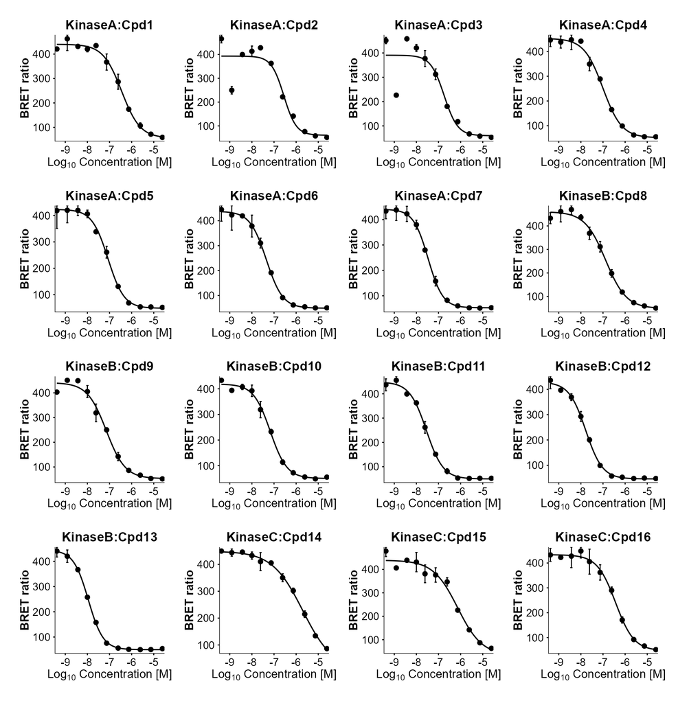

## 7.2 Multiple compounds overlaid

`plot_multiple_compounds()` overlays several curves to highlight differences in potency or shape:

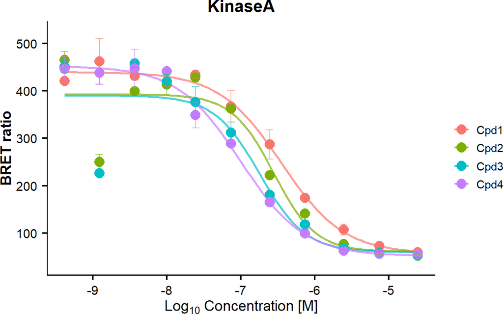

[figure not shown]

```r
plot_multiple_compounds(
  results          = drc_res,
  compound_indices = 1:4,
  plate            = "plate_01",
  y_limits         = NULL,
  show_error_bars  = TRUE,
  verbose          = FALSE
)
```

## 7.3 The same compound across plates

`compare_plates_drc()` makes one figure per construct-compound that appears on more than one plate, useful for cross-plate consistency QC. The bundled `plate_02` repeats four of `plate_01`’s compounds under the same construct, so four cross-plate plots are produced:

```r
compare_out <- file.path(tempdir(), "dosefitr_nanobret_compare")
dir.create(compare_out, showWarnings = FALSE)

cmp_res <- compare_plates_drc(
  batch_drc_result = drc_res,
  compare_by       = "construct_compound",
  output_dir       = compare_out,
  min_plates       = 2,
  verbose          = FALSE
)

list.files(compare_out, pattern = "\\.png$")
```

```
#> [1] "KinaseA__Cpd1.png"  "KinaseA__Cpd5.png"  "KinaseB__Cpd13.png"
#> [4] "KinaseB__Cpd9.png"
```

`compare_plates_drc()` returns plot objects in `$plots` and writes each one to disk; you can inspect them with any image viewer or load them inline.

# 8 Export

The main results are already exported by the batch functions: with `generate_reports = TRUE` (the default), `batch_ratio_analysis()` writes a per-plate result workbook plus a consolidated report, and `batch_drc_analysis()` writes the fitted `drc_results` and its own consolidated report. The Scarab table below is an **optional, lab-specific** step for groups that submit to the SGC Scarab system; skip it if you do not.

## 8.1 Scarab-format submission tables (optional, lab-specific)

`scarab_table()` produces a wide submission table in the SGC Scarab format, one column per compound:

```r
sc_01 <- scarab_table(
  results_list        = ratio_res,
  drc_results_list    = drc_res,
  plate_name          = "plate_01",
  date                = format(Sys.Date(), "%y%m%d"),
  experimenter_abbrev = "DEMO",
  save                = FALSE
)

dim(sc_01)
```

```
#> [1] 76 17
```

```r
head(sc_01[, 1:5], 6)
```

```
#>                            Field                       X4
#> 1                         Kinase                  KinaseA
#> 2               nLuc Orientation                        C
#> 3                       Compound                     Cpd1
#> 4 Experiment Type (lysed/intact)              intact mode
#> 5                  Experiment ID 260905-DEMO-KinaseA-Cpd1
#> 6                      Cell line                  HEK293T
#>                         X5                       X6                       X7
#> 1                  KinaseA                  KinaseA                  KinaseA
#> 2                        C                        C                        C
#> 3                     Cpd2                     Cpd3                     Cpd4
#> 4              intact mode              intact mode              intact mode
#> 5 260905-DEMO-KinaseA-Cpd2 260905-DEMO-KinaseA-Cpd3 260905-DEMO-KinaseA-Cpd4
#> 6                  HEK293T                  HEK293T                  HEK293T
```

# 9 Reading the quality metrics

The result of `batch_ratio_analysis()` includes a per-plate quality block printed at run time. The key numbers to watch:

- **S/B (signal-to-background)** – ratio of mean 0 % control wells to mean 100 % control wells in the acceptor channel. Values above 5 indicate a usable dynamic range.
- **Z-prime** – a unitless robustness statistic combining S/B with control variability. Values above 0.5 are usable, above 0.7 are excellent.
- **CV %** – coefficient of variation between technical replicates. Anything under 10 % is well-behaved.

For a complete description of each fit-level quality label (`Good curve`, `Wide LogIC50/LogEC50 CI range`, `Top too low`, etc.) see the help page of `batch_drc_analysis()`.

# 10 See also

- `vignette("dosefitr", package = "dosefitr")` – introduction, motivation, and comparison with related packages.
- `vignette("dosefitr-viability", package = "dosefitr")` – the viability / proliferation pipeline using the same plate layout.
- `?batch_ratio_analysis`, `?batch_drc_analysis`, `?rout_outliers_batch` – parameter-level documentation.